# HW2

## Question 0

## Question 1

### Question 1A

```r
q1a <- country_population %>%
  filter(
    year >= 1990,
    year<= 2010
  ) %>%
  group_by(
    iso3c,
    country
  ) %>%
  summarise(
    mean_population = mean(population)
  )
head(q1a)
```

```
#> # A tibble: 6 × 3
#> # Groups:   iso3c [6]
#>   iso3c country              mean_population
#>   <chr> <chr>                          <dbl>
#> 1 ABW   Aruba                         85839.
#> 2 AFG   Afghanistan                19819866.
#> 3 AGO   Angola                     16829911.
#> 4 ALB   Albania                     3095489.
#> 5 AND   Andorra                       67825.
#> 6 ARE   United Arab Emirates        3858774.
```

### Question 1B

```r
q1b <- country_birth %>%
  filter(
    year >= 1990,
    year<= 2010
  ) %>%
  select(
    iso3c,
    year,
    life_expect
  ) %>%
  drop_na() %>%
  group_by(
    iso3c
  ) %>%
  summarise(
    min_life_expect = min(life_expect),
    max_life_expect = max(life_expect)
  ) %>%
  ungroup() %>%
  mutate(
    range_life_expect = max_life_expect - min_life_expect
  )

head(q1b)
```

```
#> # A tibble: 6 × 4
#>   iso3c min_life_expect max_life_expect range_life_expect
#>   <chr>           <dbl>           <dbl>             <dbl>
#> 1 ABW              73.4            75.0              1.56
#> 2 AFG              49.9            59.0              9.11
#> 3 AGO              41.1            50.7              9.52
#> 4 ALB              71.9            77.0              5.14
#> 5 ARE              71.7            76.7              4.96
#> 6 ARG              71.5            75.5              3.94
```

### Question 1C

```r
country_both <- inner_join(x = q1a, y = q1b, by = "iso3c")

head(country_both, n=10)
```

```
#> # A tibble: 10 × 6
#> # Groups:   iso3c [10]
#>    iso3c country              mean_population min_life_expect max_life_expect range_life_expect
#>    <chr> <chr>                          <dbl>           <dbl>           <dbl>             <dbl>
#>  1 ABW   Aruba                         85839.            73.4            75.0              1.56
#>  2 AFG   Afghanistan                19819866.            49.9            59.0              9.11
#>  3 AGO   Angola                     16829911.            41.1            50.7              9.52
#>  4 ALB   Albania                     3095489.            71.9            77.0              5.14
#>  5 ARE   United Arab Emirates        3858774.            71.7            76.7              4.96
#>  6 ARG   Argentina                  36972314.            71.5            75.5              3.94
#>  7 ARM   Armenia                     3211816.            67.7            74.2              6.49
#>  8 ATG   Antigua and Barbuda           74385.            71.2            75.3              4.15
#>  9 AUS   Australia                  19200991.            77.0            81.7              4.70
#> 10 AUT   Austria                     8057573.            75.6            80.6              5.01
```

Num rows: 202

Num cols: 6

## Question 2

### Question 2A

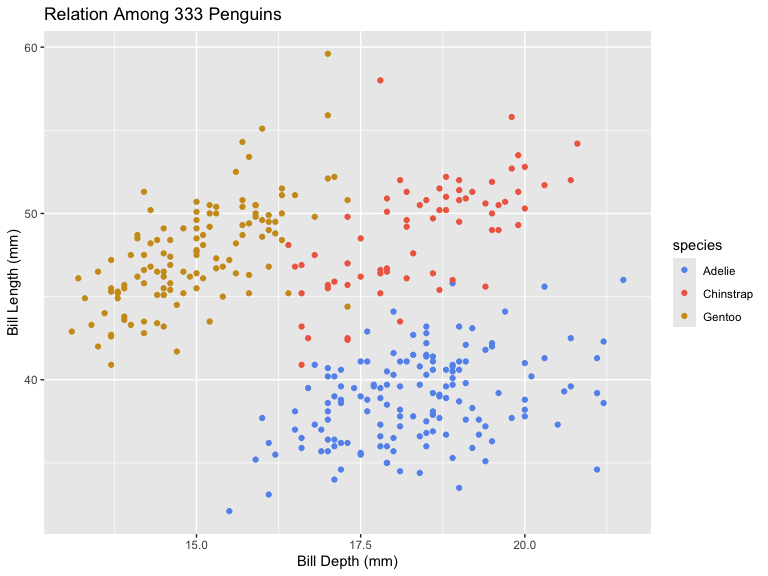

```r
penguins %>%
  ggplot(aes(x = bill_depth_mm, y = bill_length_mm,
             color = species)) +
  geom_point() +
  scale_color_manual(values=c("Adelie" = "cornflowerblue",
                              "Chinstrap" = "coral2",
                              "Gentoo" = "goldenrod3")) +
  labs(x = "Bill Depth (mm)",
       y = "Bill Length (mm)",
       title = paste0("Relation Among ", as.character(nrow(penguins))," Penguins"))
```

### Question 2B

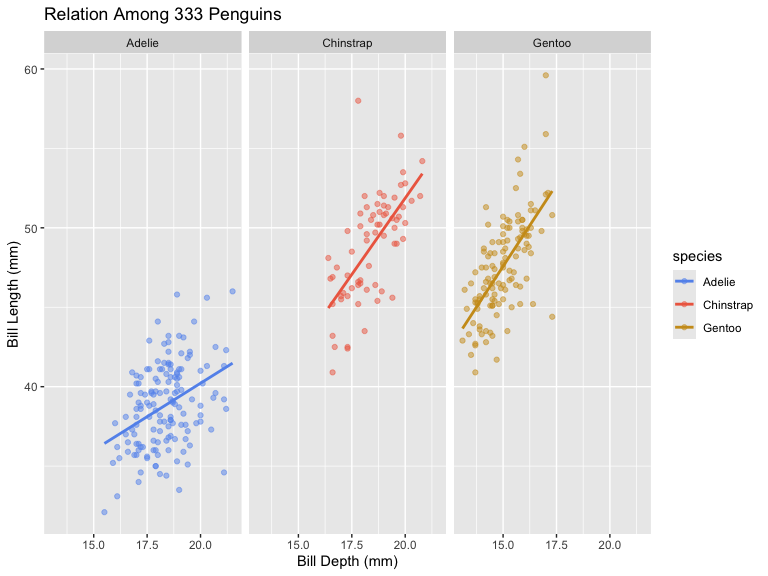

```r
penguins %>%
  ggplot(aes(x = bill_depth_mm, y = bill_length_mm,
             color = species)) +
  geom_point(alpha=0.5) +
  scale_color_manual(values=c("Adelie" = "cornflowerblue",
                              "Chinstrap" = "coral2",
                              "Gentoo" = "goldenrod3")) +
  geom_smooth(method = "lm", se = FALSE) +
  labs(x = "Bill Depth (mm)",
       y = "Bill Length (mm)",
       title = paste0("Relation Among ", as.character(nrow(penguins))," Penguins")) +
  facet_wrap(~species, nrow = 1)
```

## Question 3

### Question 3A

generate_random_graph() creates an n by n matrix, where n is an integer input to the function. The entries in this matrix are randomly selected such that they are 0 90% of the time and 1 10% of the time. To symmetrize the matrix, add the matrix to its inverse and replace all non-zero entries with 1. Additionally, set the diagonal of the matrix to all 1. Then, take the first 20% of the rows and columns (rounded up to nearest whole number), and set all equal to 1. The nodes are then shuffled and the function returns the shuffled matrix and a list of numbers to undo the shuffling.

### Question 3B

pivot_longer_heatmap() creates a new row for every entry in adj_mat. If adj_mat is 20x20, it will create a row for [1,1], where X = 1, Y = 1, and value is the entry at this position in adj_mat, another row for [1,2], …. There will be n x n rows in the result.

### Question 3C

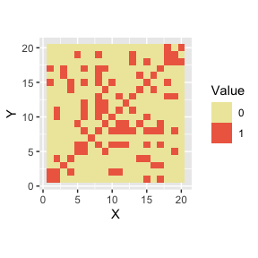

```r
set.seed(2)

result <- generate_random_graph(n = 20)
adj_mat <- result$adj_mat
mat_long <- pivot_longer_heatmap(adj_mat)
ggplot(aes(x=X, y=Y, fill=as.factor(Value)), data=mat_long) +
  geom_tile() +
  coord_fixed(ratio = 1) +
  scale_fill_manual(values = c("1" = "coral2", "0" = "palegoldenrod")) +
  labs(fill = "Value")
```

### Question 3D

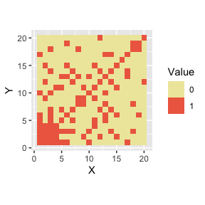

```r
adj_mat2 <- result$adj_mat[result$rev_order, result$rev_order]
mat_long <- pivot_longer_heatmap(adj_mat2)
ggplot(aes(x=X, y=Y, fill=as.factor(Value)), data=mat_long) +
  geom_tile() +
  coord_fixed(ratio = 1) +
  scale_fill_manual(values = c("1" = "coral2", "0" = "palegoldenrod")) +
  labs(fill = "Value")
```

The dense red at the bottom left is the clique that was introduced in the generate_random_graph code. The plot tells us that there are 4 nodes that are all pairwise connected in adj_mat2, and thus there are also 4 nodes that are pairwise connected in adj_mat (but it is harder to visualize in adj_mat).

## Question 4

- test on matrices that are not square to make sure it fails
- test on simulated matrices with known clique sizes
- test on matrices and the same matrices with shuffled nodes to make sure the result is the same
- test on null/empty matrices as an edge case, the function should return 0 and not an error

## Question 5